# **Thresholding, Binarization & Adaptive Thresholding**

# 2. **Adaptive Thresholding** - MOSLASHUVCHAN THRESHOLDING

1. ADAPTIVE_THRESH_MEAN_C
2. THRESH_OTSU

#### **cv2.adaptiveThreshold Parameters**

`**cv2.adaptiveThreshold**(src, maxValue, adaptiveMethod, thresholdType, blockSize, C[, dst]) → dst`

- **src** – Source 8-bit single-channel image.
- **dst** – Destination image of the same size and the same type as src .
- **maxValue** – Non-zero value assigned to the pixels for which the condition is satisfied. See the details below.
- **adaptiveMethod** – Adaptive thresholding algorithm to use, ADAPTIVE_THRESH_MEAN_C or ADAPTIVE_THRESH_GAUSSIAN_C . See the details below.
- **thresholdType** – Thresholding type that must be either THRESH_BINARY or THRESH_BINARY_INV .
- **blockSize** – Size of a pixel neighborhood that is used to calculate a threshold value for the pixel: 3, 5, 7, and so on.
- **C** – Constant subtracted from the mean or weighted mean. Normally, it is positive but may be zero or negative as well.

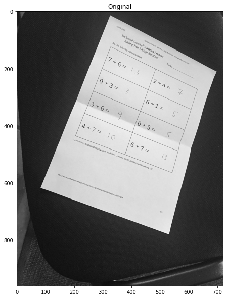

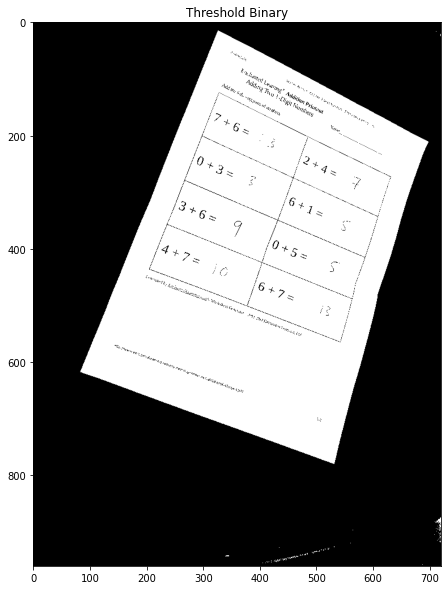

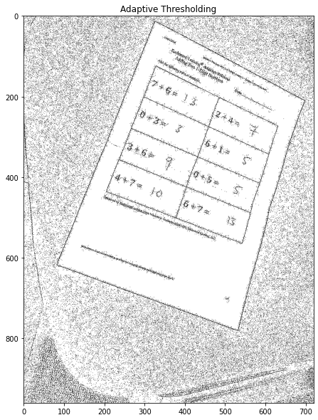

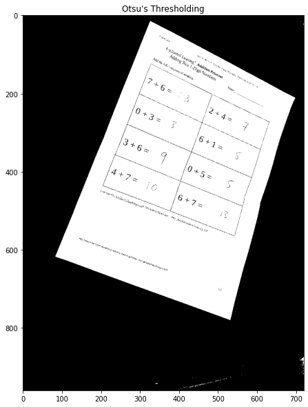

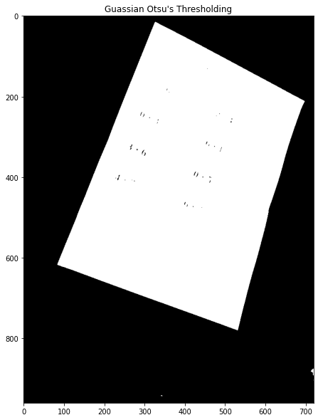

```python
#yaxshiroq natija olish uchun play around qilish kerak bu qiymatlar bilan.

image = cv2.imread('Datasets/images/scan.jpg',0)
imshow("Original", image)

# 127 pasti valuelar  0 ga (black) va undan yuqori barcha valuelar 255 (white) ga aylanadi.
ret,thresh1 = cv2.threshold(image, 127, 255, cv2.THRESH_BINARY)
imshow('Threshold Binary', thresh1)

# Thresholdingdan avval bluring qilish noisyni yoqotish uchun foydali hisoblanadi.
#image = cv2.GaussianBlur(image, (3, 3), 0)

# Adaptive thresholding: 3- blocksize neighboorhood  pixellar uchun, 5 - C value hisoblanadi.
#yaxshiroq natija olish uchun play around qilish kerak bu qiymatlar bilan.
thresh = cv2.adaptiveThreshold(image, 255, cv2.ADAPTIVE_THRESH_MEAN_C, cv2.THRESH_BINARY, 3, 5)
imshow("Adaptive Thresholding", thresh)

#Otsu esa kopincha yaxshiroq natija beradi. boshqa thersholdinglar bilan birga ishlatiladi
_, otsu = cv2.threshold(image, 0, 255, cv2.THRESH_BINARY + cv2.THRESH_OTSU)
imshow("Otsu's Thresholding", otsu)

# Blurlarngan rasmdan keyin Otsu thresholdingni qo'llash
blur = cv2.GaussianBlur(image, (5,5), 0)
_, th3 = cv2.threshold(blur, 0, 255, cv2.THRESH_BINARY + cv2.THRESH_OTSU)
imshow("Guassian Otsu's Thresholding", th3)
```

# 3. **SkImage Threshold Local**

`threshold_local(image, block_size, offset=10)`

The threshold_localcalculates thresholds in regions with a characteristic size `block_size` surrounding each pixel (i.e. local neighborhoods). Each threshold value is the weighted mean of the local neighborhood minus an `offset` value

https://scikit-image.org/docs/stable/auto_examples/applications/plot_thresholding.html

[figure not shown]

```python
from skimage.filters import threshold_local

image = cv2.imread('Datasets/images/scan.jpg',0)

# Keyin adaptive thresholdingni amalga oshiramiz
T = threshold_local(image, 35, offset=15, method="gaussian") #gaus qollasak blur qilbi noisy kamaytiriladi

#THresholdingni qollash uchun.
#Orginal rasmdan thresholdan katta qiymatni ushlab olishimiz lozim
binray_threshold = image > T
imshow("threshold_local", thresh)
```